# MATH1115 Final Practical Exam

# Instructions

This is a selection of questions taken from a past exam paper. Answers are not provided by default but can be demonstrated by a tutor.

## Getting started

1. You have been provided a data file, `PlaneCrashes.csv` and *this* R Markdown file to complete the exam.
2. Read the data briefing. It will provide useful information about the variables in the dataset.
3. Attempt all questions. You have **100 minutes**, including reading time of 10 minutes.
4. All answers **must** be presented in the appropriate sections and *numbered* according to the question.
5. All plots **must** be in `ggplot2`. Note that diagnostic plots (Residual, QQ plots) that are used to test for data assumptions may remain as base R plots.
6. **Do not edit this template.** Only provide answers in the appropriate blocks (see below).
7. For all hypothesis testing questions, unless stated otherwise, assume that $\alpha = 0.05$.

## Writing your answers

- All answers should be written within the answer alert blocks provided. These alert boxes look like below in the source document:

```
::: {.alert .alert-info}

Write your answers within this block, including code chunks.

:::
```

## Submission

1. When the time is up (100 min), you will have 15 minutes to submit your assignment.
2. **Only .html file submissions are accepted.**
3. You will not be able to submit an incomplete .Rmd file.
4. Rename your final file to `XXXXXXXXXX_MATH1115_Exam.html` where `XXXXXXXXXX` is your SID.

## Acknowledgement

Please acknowledge that you have read the instructions above by replacing `XXXXXXXXXX` with your SID.

**I have acknowledged the instructions in this file. My SID is**:

470033070

# Briefing on Data

1. `date`: Date of accident (January 01, 2001 format)
2. `time`: Local time (24 hour format)
3. `location`: location information
4. `operator`: Airline or aircraft operator.
5. `flight_no`: Flight number
6. `route`: Complete or partial route flown prior to accident.
7. `ac_type`: Aircraft type
8. `registration`: ICAO registration
9. `cn_ln`: Construction number/Line number
10. `aboard`: Total aboard (passengers/crew)
11. `air`: Total killed in air (passengers/crew)
12. `ground`: Total killed on the ground
13. `total`: Total killed in crash

There are many missing observations denoted with a `?`.

## PART A: SETTING UP

Before beginning any data analysis/wrangling, it is advisable to first set up the .rmd document by loading any required packages and data. This keeps the document neat and readable.

1. Install and load the `tidyverse` package

```r
library(tidyverse)
```

2. Save the `PlaneCrashes.csv` dataset available from the Canvas Exam page and replace the code below so that the file is loaded from your local folder, and not the web link.

```r
plane <- read.csv("data/PlaneCrashes.csv")
plane_CLEAN <- read_csv("data/PlaneCrashesCLEAN.csv")
```

```
## * `` -> ...1
```

## PART B: CLEANING DATA

The dataset has many variables that are not in a helpful format. Therefore, the dataset needs to be cleaned and wrangled into something that would be useful for further analysis.

1. Change the single `date` variable into three variables: `month`, `day`, `year`.

```r
library(lubridate)
plane %>%
  mutate(date = mdy(date)) %>%
  mutate(year = year(date)) %>%
  mutate(month = month(date)) %>%
  mutate(day = day(date)) -> plane
```

Now we have our 3 new variables.

2. Keep only the total number `aboard` and total number of `air` deaths (i.e. the first values of the columns) and drop the rest (i.e. the passenger/crew distinction)

```r
plane_CLEAN %>%
  select(aboard, air) -> only_2
aboard <- c(max(only_2$aboard, na.rm = T))
air <- c(max(only_2$air, na.rm = T))
data.frame(
  aboard, air
)
```

```
##   aboard air
## 1    644 583
```

3. Drop these columns `flight_no`, `registration`, `cn_ln`

```r
plane %>%
  select(-flight_no, -registration, -cn_ln) -> plane
```

## PART C: INITIAL DATA ANALYSIS

Provide the following summaries/graphs and comment on the output.

1. A numerical summary for the `total` variable, including the standard deviation

```r
summary(plane_CLEAN$total)
```

```
##    Min. 1st Qu.  Median    Mean 3rd Qu.    Max.    NA's
##    0.00    3.00   10.00   21.46   23.00 2842.00      11
```

```r
sd(plane_CLEAN$total, na.rm = TRUE)
```

```
## [1] 62.09202
```

2. A graph for the `total` variable

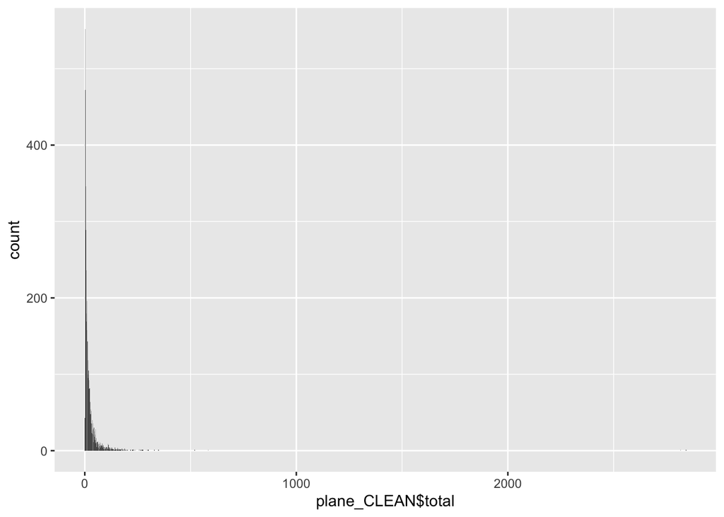

```r
ggplot(plane_CLEAN, aes(plane_CLEAN$total)) +
  geom_bar()
```

3. A graph for the total number of deaths in the 20th Century versus the 21st Century (i.e use `total` and `year`)

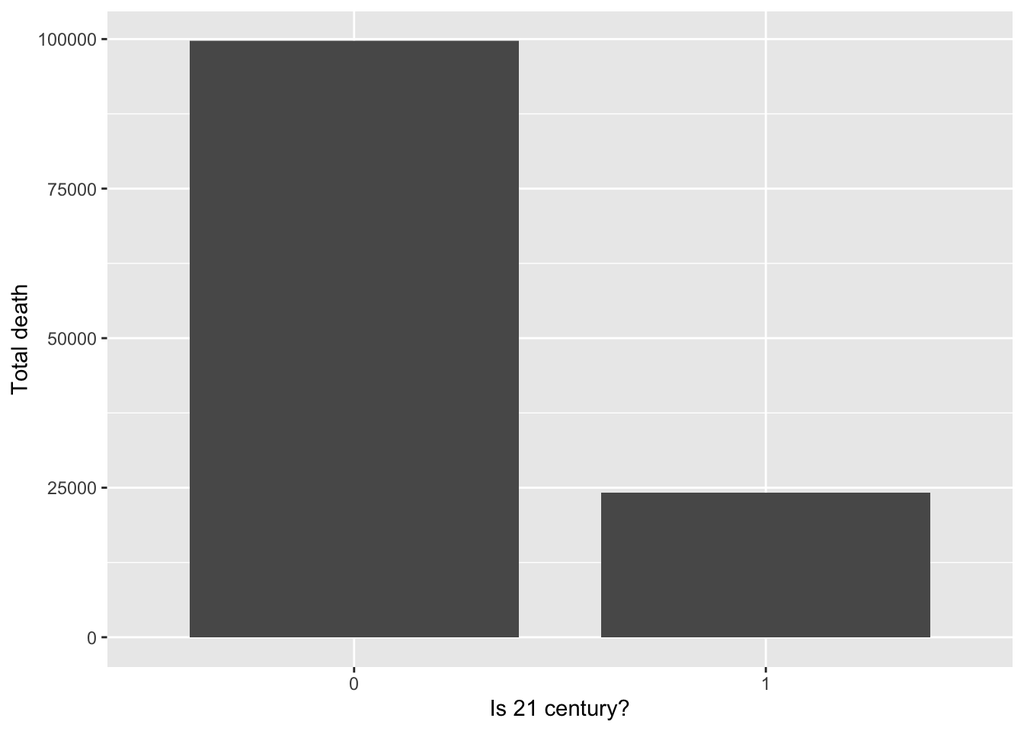

```r
plane_CLEAN %>%
  select(total, year) %>%
  mutate(is_21_century = case_when(
    year < 2000 ~ 0,
    year >= 2000 ~ 1
  )) %>%
  ggplot(aes(factor(is_21_century), total)) +
  geom_bar(stat = "identity", width = 0.8) +
  xlab("Is 21 century?") +
  ylab("Total death")
```

## PART D: BINOMIAL

1. Create a table that looks like the one below where `all` is whether all passengers died (or not) and `n` is the number of crashes that fall in that category.

| all | n |
| --- | --- |
| NO | 2069 |
| YES | 3674 |

```r
data.frame(all = c('no', 'yes'),
           n = c(2069, 3674))
```

```
##   all    n
## 1  no 2069
## 2 yes 3674
```

2. Calculate the chance of selecting a crash where all aboard died

```r
3674 / (2069 + 3674)
```

```
## [1] 0.6397353
```

3. Model this sampling by a box model with 50 draws (with replacement) and calculate the expected value and standard error for the total number of crashes where all aboard died (i.e. `YES`) in the sample

```r
box <- c(rep(0, times = 10000000 - 6397353), rep(1, times = 6397353))

ev <- mean(box) * 50

library(multicon)
se <- popsd(box) * sqrt(50)

c(ev,se)
```

```
## [1] 31.986765  3.394658
```

## PART E: CHI-SQUARE

We are interested in whether there is a difference in crash occurrence where everyone aboard died between the months of the year. Perform a chi-squared test for independence to test this hypothesis. Report following the H A P T C process.

1. First create a contingency table like the following:

| Month | NO | YES |
| --- | --- | --- |
| January | 187 | 348 |
| February | 153 | 276 |
| March | 157 | 328 |
| April | 144 | 269 |
| May | 151 | 249 |
| June | 159 | 258 |
| July | 179 | 293 |
| August | 186 | 333 |
| September | 190 | 316 |
| October | 163 | 332 |
| November | 181 | 322 |
| December | 219 | 350 |

The `aboard` in `plane` is damaged by its weird encoding and `plane_CLEAN` does not have a date for month whatsoever.

2. Now perform the chi-squared test

Same as above.

## PART F: SIMPLE LINEAR REGRESSION

Now we’re interested in seeing if there is a linear relationship between crash occurence and Year from 1960 onwards.

1. Subset the data to get the number of crashes per year from 1960 onwards.

!Data Integrity Issue

2. Calculate the linear correlation coefficient.

!Data Integrity Issue

3. Check that Simple Linear Regression (SLR) assumptions are met by plotting the standardised residuals vs fitted values plot and a qqnorm plot. Comment on the plot and suggest alternatives if assumption(s) are not met.

!Data Integrity Issue

4. Assuming that all assumptions are met, report the results of the SLR following the H A P T C process

!Data Integrity Issue

22. Now plot the data as a scatterplot with the linear regression line

!Data Integrity Issue

## PART G: EXECUTIVE SUMMARY

Include an executive summary covering the main points of this dataset/report.

Whoever decide to put these data sheets into an exam, Please get out.